# 期末專題報告

2019 RPB - Group 5

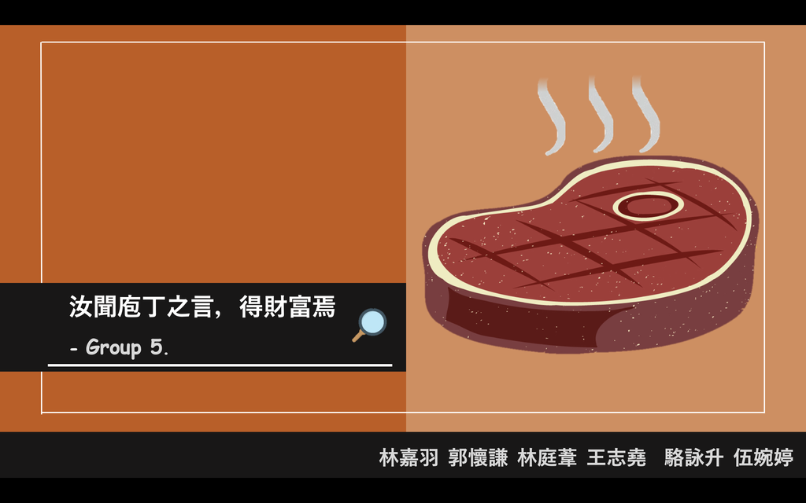

## 一、前置作業

### 1. 環境設定

- 將環境中的變數清除乾淨
- 設定地區參數為美國
- 將我們需要的 packages 都 library 進來

```r
rm(list=ls(all=T))
Sys.setlocale("LC_ALL","C")
```

```
[1] "C/C/C/C/C/zh_TW.UTF-8"
```

```r
library(dplyr)
library(ggplot2)
library(caTools)
library(Matrix)
library(slam)
library(rpart)
library(rpart.plot)
library(corrplot)
library(tidyr)
library(d3heatmap)
```

### 2. 讀取資料

- Z : 原始資料
- X : 將 Z 中屬於單日同一筆消費者的交易綁起來
- A : 將 X 中單個顧客的所有交易綁起來
- 我們取用 tf2.rdata 中的 spl 以及 spl2，並從 tf0.rdata 中取用 A0、X0 及 Z0。
- 過程中並沒有更動到次序，因此 spl 及 spl2 並不會有資料欄位錯誤的問題。

```r
load("data/tf2.rdata")
rm(A)
rm(X)
rm(Z)
load("data/tf0.rdata")
CopyA <- A0
CopyX <- X0
CopyZ <- Z0
```

## 二、處理資料與變數擴增

### 1. 資料框 Z 的欄位變更

- **加入新變數**
- grossmargin : 為該品項交易的毛利率。
- grossmargin = ( 商品總價 - 商品總成本 ) / 商品總價

```r
Z = subset(CopyZ, date < as.Date("2001-02-01"))
Z$grossmargin = (Z$price-Z$cost)/Z$price
```

### 2. 資料框 X 的欄位變更

- **加入新變數**
- month : 為該筆交易的月份。
- spec : 單筆交易之商品平均毛利率。
- spec = 單筆交易總毛利率 / 該筆交易總商品數量
- poorbitch : 單筆交易有多少比例的商品毛利率是負值 ( 公司賠賣 )。
- poorbitch = 單筆交易商品毛利率 <0 的總數 / 該筆交易總商品數量
- weekday : 為該筆交易的星期數值，並由星期一排到星期日。

```r
X = group_by(Z, tid) %>% summarise(
 date = first(date),  # 交易日期
 month = months(date),
 spec = sum(grossmargin*qty)/sum(qty),
 poorbitch = sum(as.numeric(grossmargin<0)*qty)/sum(qty),
 weekday = factor(weekdays(date),levels = c("Monday", "Tuesday", "Wednesday", "Thursday","Friday","Saturday","Sunday")),
 cust = first(cust),  # 顧客 ID
  age = first(age),    # 顧客 年齡級別
  area = first(area),  # 顧客 居住區別
  items = n(),                # 交易項目(總)數
  pieces = sum(qty),          # 產品(總)件數
  total = sum(price),         # 交易(總)金額
  gross = sum(price - cost)   # 毛利
) %>% data.frame  # 88387
X = subset(X, items<=64 & pieces<=98 & total<=11260)
summary(X)
```

```
      tid             date               month                spec            poorbitch           weekday
 Min.   :    1   Min.   :2000-11-01   Length:88295       Min.   :-1.93732   Min.   :0.0000   Monday   :12615
 1st Qu.:22086   1st Qu.:2000-11-23   Class :character   1st Qu.: 0.09309   1st Qu.:0.0000   Tuesday  :11288
 Median :44181   Median :2000-12-12   Mode  :character   Median : 0.16258   Median :0.0000   Wednesday: 9898
 Mean   :44184   Mean   :2000-12-15                      Mean   : 0.12344   Mean   :0.1263   Thursday :11245
 3rd Qu.:66270   3rd Qu.:2001-01-12                      3rd Qu.: 0.20933   3rd Qu.:0.1176   Friday   :10651
 Max.   :88387   Max.   :2001-01-31                      Max.   : 1.00000   Max.   :1.0000   Saturday :14587
                                                                                             Sunday   :18011
     cust               age                area               items            pieces           total
 Length:88295       Length:88295       Length:88295       Min.   : 1.000   Min.   : 1.000   Min.   :    5.0
 Class :character   Class :character   Class :character   1st Qu.: 2.000   1st Qu.: 3.000   1st Qu.:  230.0
 Mode  :character   Mode  :character   Mode  :character   Median : 5.000   Median : 6.000   Median :  522.0
                                                          Mean   : 6.948   Mean   : 9.372   Mean   :  877.6
                                                          3rd Qu.: 9.000   3rd Qu.:12.000   3rd Qu.: 1116.0
                                                          Max.   :64.000   Max.   :98.000   Max.   :10980.0

     gross
 Min.   :-1645.0
 1st Qu.:   23.0
 Median :   72.0
 Mean   :  136.2
 3rd Qu.:  174.0
 Max.   : 3217.0
```

### 3. 資料框 A 的欄位變更

- **加入新變數**
- month1f , month2f , month3f : 為十一月至一月，該顧客各月份的交易次數。
- frise : 邏輯數值。代表十一至一月各月份的交易次數是否為連續上升。
- frise = ( 十一月至十二月交易次數上升 ) && ( 十二月至一月交易次數上升 )
- weeksum : 單一顧客於週間來店的次數總和。
- weekendsum : 單一顧客於週末來店的次數總和。
- realspec : 單一顧客所有消費之商品毛利率平均值。
- realspec = 單筆交易 spec * 單筆交易商品總數量 / 交易之總商品數量
- realpoorbitch : 單一顧客所有消費之商品有多少比例毛利率是負值 ( 公司賠賣 )。
- realpoorbitch = 單筆交易 poorbitch * 單筆交易商品總數量 / 交易之總商品數量

```r
d0 = max(X$date)
A = group_by(X, cust) %>% summarise(
  r = 1 + as.integer(difftime(d0, max(date), units="days")), # recency
  s = 1 + as.integer(difftime(d0, min(date), units="days")), # seniority
  f = n(),            # frquency
  month1f = sum(month == "November"),
  month2f = sum(month == "December"),
  month3f = sum(month == "January"),
  weeksum = sum(weekday!="Saturday" & weekday!="Sunday"),
  weekendsum = sum(weekday=="Saturday")+sum(weekday=="Sunday"),
  frise = isTRUE(month2f - month1f > 0 && month3f - month2f > 0),
  realspec = sum(spec*pieces)/sum(pieces),
  realpoorbitch = sum(poorbitch*pieces)/sum(pieces),
  m = mean(total),    # monetary
  rev = sum(total),   # total revenue contribution
  raw = sum(gross),   # total gross profit contribution
  age = first(age),   # age group
  area = first(area) # area code
) %>% data.frame    # 28584
```

- 計算 A 中的 amount 以及 buy

```r
feb = filter(CopyX, date>= as.Date("2001-02-01")) %>% group_by(cust) %>% summarise(amount = sum(total))  # 16900
A = merge(A, feb, by="cust", all.x=T)
A$buy = !is.na(A$amount)
summary(A)
```

```
     cust                 r               s               f             month1f          month2f
 Length:28584       Min.   : 1.00   Min.   : 1.00   Min.   : 1.000   Min.   : 0.000   Min.   : 0.0000
 Class :character   1st Qu.:11.00   1st Qu.:47.00   1st Qu.: 1.000   1st Qu.: 0.000   1st Qu.: 0.0000
 Mode  :character   Median :21.00   Median :68.00   Median : 2.000   Median : 1.000   Median : 1.0000
                    Mean   :32.12   Mean   :61.27   Mean   : 3.089   Mean   : 1.112   Mean   : 0.9339
                    3rd Qu.:53.00   3rd Qu.:83.00   3rd Qu.: 4.000   3rd Qu.: 1.000   3rd Qu.: 1.0000
                    Max.   :92.00   Max.   :92.00   Max.   :60.000   Max.   :26.000   Max.   :21.0000

    month3f          weeksum         weekendsum      frise            realspec        realpoorbitch
 Min.   : 0.000   Min.   : 0.000   Min.   : 0.00   Mode :logical   Min.   :-1.93732   Min.   :0.00000
 1st Qu.: 0.000   1st Qu.: 1.000   1st Qu.: 0.00   FALSE:27724     1st Qu.: 0.09716   1st Qu.:0.00000
 Median : 1.000   Median : 1.000   Median : 1.00   TRUE :860       Median : 0.16064   Median :0.03333
 Mean   : 1.043   Mean   : 1.949   Mean   : 1.14                   Mean   : 0.12562   Mean   :0.12825
 3rd Qu.: 1.000   3rd Qu.: 2.000   3rd Qu.: 1.00                   3rd Qu.: 0.20159   3rd Qu.:0.15152
 Max.   :25.000   Max.   :44.000   Max.   :18.00                   Max.   : 0.47778   Max.   :1.00000

       m                rev             raw              age                area               amount
 Min.   :    8.0   Min.   :    8   Min.   : -742.0   Length:28584       Length:28584       Min.   :    8
 1st Qu.:  359.4   1st Qu.:  638   1st Qu.:   70.0   Class :character   Class :character   1st Qu.:  454
 Median :  709.5   Median : 1566   Median :  218.0   Mode  :character   Mode  :character   Median :  993
 Mean   : 1012.4   Mean   : 2711   Mean   :  420.8                                         Mean   : 1499
 3rd Qu.: 1315.0   3rd Qu.: 3426   3rd Qu.:  535.0                                         3rd Qu.: 1955
 Max.   :10634.0   Max.   :99597   Max.   :15565.0                                         Max.   :28089
                                                                                           NA's   :15342
    buy
 Mode :logical
 FALSE:15342
 TRUE :13242
```

- avgbuy : 單一顧客所購買的商品平均單價
- avgbuy = 所有交易之商品總價 / 所有交易之商品總數量

```r
Y = group_by(Z, cust) %>% summarise(
  avgbuy = sum(price)/sum(qty) )%>% data.frame
A$avgbuy = Y$avgbuy[Y$cust %in% A$cust]
```

- W1 - W7 : 單一顧客於週內每天會進行交易的機率。
- ( 並無更動 Tony 的程式碼 )

```r
X = X %>% mutate(wday = format(date, "%w"))
table(X$wday)
```

```
    0     1     2     3     4     5     6
18011 12615 11288  9898 11245 10651 14587
```

```r
mx = xtabs(~ cust + wday, X)
dim(mx)
```

```
[1] 28584     7
```

```r
mx[1:5,]
```

```
          wday
cust       0 1 2 3 4 5 6
  00001069 1 1 0 0 0 0 0
  00001113 2 1 0 0 0 0 1
  00001359 0 1 0 0 0 0 0
  00001823 0 1 0 1 1 0 0
  00002189 0 0 0 1 0 0 1
```

```r
mx = mx / rowSums(mx)
mx[1:5,]
```

```
          wday
cust               0         1         2         3         4         5         6
  00001069 0.5000000 0.5000000 0.0000000 0.0000000 0.0000000 0.0000000 0.0000000
  00001113 0.5000000 0.2500000 0.0000000 0.0000000 0.0000000 0.0000000 0.2500000
  00001359 0.0000000 1.0000000 0.0000000 0.0000000 0.0000000 0.0000000 0.0000000
  00001823 0.0000000 0.3333333 0.0000000 0.3333333 0.3333333 0.0000000 0.0000000
  00002189 0.0000000 0.0000000 0.0000000 0.5000000 0.0000000 0.0000000 0.5000000
```

```r
A = data.frame(rownames(mx), as.matrix.data.frame(mx)) %>%
  setNames(c("cust","W1","W2","W3","W4","W5","W6","W7")) %>%
  right_join(A, by='cust')
```

```
Column `cust` joining factor and character vector, coercing into character vector
```

- r2 , s2 , f2 : 分別為 r , s , f 的平方項。
- 之所以會這樣設定是因為我們懷疑 r , s , f 與應變數的關係可能並非線性相關。

```r
A$r2 <- A$r^2
A$s2 <- A$s^2
A$f2 <- A$f^2
```

### 4. 資料框 X 及 Z 核對

- 將 A 中不存在的顧客從 X 及 Z 中剔除。

```r
X = subset(X, cust %in% A$cust & date < as.Date("2001-02-01"))
Z = subset(Z, cust %in% A$cust & date < as.Date("2001-02-01"))
```

- 計算 A2

```r
A2 = subset(A, buy) %>% mutate_at(c("m","rev","amount"), log10)
```

### 5. 資料集任意門

- 將處理過的資料集存起來，方便下次直接讀取使用

```r
save(X, X0, Y, Z, Z0, A, A0, A2, feb, CopyA, CopyX, CopyZ, file = "NewDataSet_V2.RData")
```

- 讀取資料任意門

```r
load("NewDataSet_V2.RData")
```

## 三、資料視覺化

### 1. 每次交易訂單總額熱圖

- 以 area 及 age 分群 , 並過濾掉未知資訊的資料不畫
- 重點 (a) 106 區每次交易訂單總額明顯較高
- 重點 (b) 115/221 區每次交易訂單總額明顯較低
- 重點 (c) 25 歲以下每次交易訂單總額明顯較低
- 重點 (d) 65 歲以上每次交易訂單總額明顯較低

```r
Btemp <- X %>% group_by(area, age) %>% summarise(avggross = mean(total)) %>% spread(., age, avggross) %>% as.data.frame
rownames(Btemp) <- Btemp$area
Btemp <- Btemp[,-1]
Btemp[-8,-11] %>% as.data.frame.matrix() %>% d3heatmap(F,F,col=colorRamp(c('lightyellow','wheat','orangered')))
```

[interactive chart not shown]

- 整體平均值

```r
mean(X$total)
```

[output not shown]

- 以 area 分群平均值

```r
X%>% group_by(area) %>% summarise(avg = mean(total))
```

[output not shown]

- 以 age 分群平均值

```r
X%>% group_by(age) %>% summarise(avg = mean(total))
```

[output not shown]

### 2. 購買之商品平均毛利熱圖

- 以 area 及 age 分群 , 並過濾掉未知資訊的資料不畫 , 並忽略 others 不看
- 重點 (a) 106 區購買之商品平均毛利明顯較高
- 重點 (b) 115/221 區購買之商品平均毛利明顯較低
- 重點 (c) 25 歲以下購買之商品平均毛利明顯較低
- 重點 (d) 65 歲以上購買之商品平均毛利明顯較低

```r
Btemp <- Z %>% group_by(area, age) %>% summarise(avggross = mean(price - cost)) %>% spread(., age, avggross) %>% as.data.frame

rownames(Btemp) <- Btemp$area
Btemp <- Btemp[,-1]
Btemp[-8,-11] %>% as.data.frame.matrix() %>% d3heatmap(F,F,col=colorRamp(c('lightyellow','wheat','orangered')))
```

[output not shown]

- 整體平均值

```r
mean(Z$price - Z$cost)
```

[output not shown]

- 以 area 分群平均值

```r
Z %>% group_by(area) %>% summarise(avg =mean(price - cost))
```

[output not shown]

- 以 age 分群平均值

```r
Z %>% group_by(age) %>% summarise(avg =mean(price - cost))
```

[output not shown]

### 3. 過去三個月平均來店次數熱圖

```r
Ctemp <- A %>% group_by(area, age) %>% summarise(avgfreq = mean(f)) %>% spread(., age, avgfreq) %>% as.data.frame
```

```
There were 41 warnings (use warnings() to see them)
```

```r
rownames(Ctemp) <- Ctemp$area
Ctemp <- Ctemp[,-1]
Ctemp[-8,-11] %>% as.data.frame.matrix() %>% d3heatmap(F,F,col=colorRamp(c('lightyellow','wheat','orangered')))
```

[interactive chart not shown]

- 整體平均值

```r
mean(A$f)
```

[output not shown]

- 以 area 分群平均值

```r
A %>% group_by(area) %>% summarise(avgfreq = mean(f, na.ram =T))
```

| area | avgfreq |
| --- | --- |
| z105 | 1.897756 |
| z106 | 2.112388 |
| z110 | 1.994004 |
| z114 | 2.051181 |
| z115 | 3.783385 |
| z221 | 3.255065 |
| zOthers | 2.217890 |
| zUnknown | 4.261776 |

### 4. 顧客數量分佈熱圖

- 以 area 及 age 分群 , 並過濾掉未知資訊的資料不畫 , 並忽略 others 不看
- 重點 (a) 115/221 區佔了絕大多數的顧客組成

[interactive chart not shown]

## 四、模型建置

### 1. 分割 Training 及 Testing Dataset

- 依照 tf2.rdata 中的 spl , spl2 分割資料。

```r
TR = subset(A, spl)
```

```
There were 32 warnings (use warnings() to see them)
```

```r
TS = subset(A, !spl)
TR2 = subset(A2, spl2)
TS2 = subset(A2, !spl2)
```

### 2. 模型一、羅吉斯模型 - 手動挑選變數

- **手動篩選出模型中較顯著、有影響力之變數**
- AUC = 0.7586

```r
logis_m1_handcraft = glm(buy ~ month1f + month2f + realspec +
                 raw + area + avgbuy + r2 + s2 + f2 + log(m) + log(rev), TR[,c(9:24,26:30)], family=binomial())
```

```
glm.fit: fitted probabilities numerically 0 or 1 occurred
```

```r
summary(logis_m1_handcraft)
```

```
Call:
glm(formula = buy ~ month1f + month2f + realspec + raw + area +
    avgbuy + r2 + s2 + f2 + log(m) + log(rev), family = binomial(),
    data = TR[, c(9:24, 26:30)])

Deviance Residuals:
    Min       1Q   Median       3Q      Max
-3.5609  -0.8491  -0.6604   0.9889   2.4931

Coefficients:
               Estimate Std. Error z value Pr(>|z|)
(Intercept)  -1.228e+00  1.657e-01  -7.413 1.24e-13 ***
month1f      -1.841e-01  3.184e-02  -5.782 7.39e-09 ***
month2f      -6.696e-02  2.666e-02  -2.511  0.01203 *
realspec     -6.913e-01  1.192e-01  -5.799 6.66e-09 ***
raw          -4.055e-05  4.678e-05  -0.867  0.38596
areaz106     -4.456e-02  1.332e-01  -0.335  0.73790
areaz110     -2.157e-01  1.053e-01  -2.048  0.04052 *
areaz114      2.367e-02  1.120e-01   0.211  0.83266
areaz115      2.542e-01  9.749e-02   2.607  0.00912 **
areaz221      1.782e-01  9.821e-02   1.814  0.06962 .
areazOthers  -3.922e-02  1.052e-01  -0.373  0.70938
areazUnknown -1.836e-01  1.223e-01  -1.502  0.13314
avgbuy       -7.830e-04  1.802e-04  -4.345 1.39e-05 ***
r2           -5.726e-05  1.274e-05  -4.496 6.93e-06 ***
s2            5.525e-05  1.152e-05   4.797 1.61e-06 ***
f2            9.761e-03  1.458e-03   6.696 2.14e-11 ***
log(m)       -1.079e+00  6.381e-02 -16.906  < 2e-16 ***
log(rev)      1.125e+00  6.196e-02  18.151  < 2e-16 ***
---
Signif. codes:  0 '***' 0.001 '**' 0.01 '*' 0.05 '.' 0.1 ' ' 1

(Dispersion parameter for binomial family taken to be 1)

    Null deviance: 27629  on 20007  degrees of freedom
Residual deviance: 23194  on 19990  degrees of freedom
AIC: 23230

Number of Fisher Scoring iterations: 7
```

```r
logis_m1_handcraft_pred =  predict(logis_m1_handcraft, TS, type="response")
colAUC(logis_m1_handcraft_pred, TS$buy)
```

```
                    [,1]
FALSE vs. TRUE 0.7586024
```

```r
TS2_new <- TS2
TS2_new$ProbRetain <- predict(logis_m1_handcraft, TS2, type = "response")
```

```r
c(r2.tr, r2.ts)
```

```
[1] 0.3044146 0.2724408
```

### 4. 行銷工具效益模擬

- 先將預測結果儲存起來

```r
TS2_new <- TS2
TS2_new$ProbRetain <- predict(logis_m1_handcraft, TS2, type = "response")
TS2_new$PredRevenue <- predict(lm_m2_handcraft, TS2)
```

- 還原被取 log10 的顧客消費金額

```r
TS2_new$PredRevenue <- 10^(TS2_new$PredRevenue)
```

- **依照 age 分群進行成本效益模擬**
- 參數 m = 0.15 , a = 20 , b = 15

```r
m = 0.15
a = 20
b = 15
do.call(rbind, lapply(seq(5,40,0.5), function(c){
  p = m*plogis((10/a)*(c-b))
  TS2_new %>% mutate(
    PI = ifelse(ProbRetain<=(1-p), p, 1-ProbRetain) * PredRevenue - c
  ) %>%
    group_by(age) %>% summarise(
      Cost = c,
      Group.Sz = n(),
      No.Target = sum(PI>0),
      AvgROI = mean(PI[PI>0]),
      TotalROI = sum(PI[PI>0])
    ) } ) ) %>%
  group_by(age) %>% summarise(
    Perfect_Cost = seq(5,40,0.5)[which.max(TotalROI)],
    Perfect_ROI = max(AvgROI, na.rm = T)
  )
```

| age | Perfect_Cost | Perfect_ROI |
| --- | --- | --- |
| a20 | 22.5 | 66.57553 |
| a25 | 23.5 | 112.90719 |
| a30 | 24.0 | 139.80237 |
| a35 | 24.0 | 145.82794 |
| a40 | 24.0 | 153.96025 |
| a45 | 23.5 | 131.74447 |
| a50 | 23.5 | 115.94749 |
| a55 | 23.5 | 122.17176 |
| a60 | 23.0 | 101.60926 |
| a65 | 22.5 | 63.46884 |

[output cut: 1 more lines]

- **依照 area 分群進行成本效益模擬**
- 參數 m = 0.15 , a = 20 , b = 15

```r
m = 0.15
a = 20
b = 15
do.call(rbind, lapply(seq(5,40,0.5), function(c){
  p = m*plogis((10/a)*(c-b))
  TS2_new %>% mutate(
    PI = ifelse(ProbRetain<=(1-p), p, 1-ProbRetain) * PredRevenue - c
  ) %>%
    group_by(area) %>% summarise(
      Cost = c,
      Group.Sz = n(),
      No.Target = sum(PI>0),
      AvgROI = mean(PI[PI>0]),
      TotalROI = sum(PI[PI>0])
    ) } ) ) %>%
  group_by(area) %>% summarise(
    Perfect_Cost = seq(5,40,0.5)[which.max(TotalROI)],
    Perfect_ROI = max(AvgROI, na.rm = T),
    Perfect_ROI2 = max(TotalROI, na.rm = T),
  )
```

| area | Perfect_Cost | Perfect_ROI | Perfect_ROI2 |
| --- | --- | --- | --- |
| z105 | 23.5 | 136.3408 | 12134.33 |
| z106 | 23.5 | 123.9976 | 12399.76 |
| z110 | 23.5 | 129.0768 | 41304.57 |
| z114 | 23.5 | 118.7601 | 23276.98 |
| z115 | 23.5 | 128.3454 | 201685.21 |
| z221 | 23.5 | 132.2136 | 154720.44 |
| zOthers | 23.5 | 131.7357 | 40813.88 |
| zUnknown | 23.5 | 121.9211 | 16459.35 |

## 附錄、資料來源

- 預測模型的建置以及變數為組員林嘉羽自過去 暑期課程 - 商業數據分析 中所改寫而來。